# A Guided Tour of the rajiveplus API

rajiveplus package authors

2026-05-12

```r
knitr::opts_chunk$set(
  collapse   = TRUE,
  comment    = "#>",
  fig.width  = 7,
  fig.height = 5,
  message    = FALSE,
  warning    = FALSE
)
run_heavy <- FALSE   # set to TRUE once to regenerate all cached .rds files
data_dir  <- "data"
```

## The question

What can you ask of a fitted RaJIVE model? This gallery walks through the exported user-facing functions in **rajiveplus** using one small three-block simulation. The example is deliberately light so the whole tour can run quickly; for a biological analysis, see `vignette("cll_application")`.

Each stop follows the same rhythm: fit or extract one object, inspect the output, then say what scientific question the output can answer.

### Roadmap

| Category | Functions |
| --- | --- |
| Simulation | `ajive.data.sim` |
| Core decomposition | `Rajive` |
| S3 — *rajive* class | `print`, `summary` |
| Rank accessors | `get_joint_rank`, `get_individual_rank`, `get_all_ranks` |
| Component extractors | `get_joint_scores`, `get_block_scores`, `get_block_loadings`, `get_block_matrix` |
| Diagnostic extraction | `extract_components` (5 `what` modes) |
| Decomposition visualization | `data_heatmap`, `decomposition_heatmaps_robustH` |
| Variance explained | `showVarExplained_robust`, `plot_variance_explained` |
| Score plots | `plot_scores`, `plot_components` (`pairs`, `density`) |
| AJIVE diagnostic plots | `plot_components` (`rank_threshold`, `bound_distributions`, `ajive_diagnostic`) |
| Feature visualization | `plot_components` (`top_features`, `component_heatmap`) |
| S3 autoplot / fortify | `autoplot`, `fortify` |
| Feature ranking | `rank_features` (4 modes) + 3 wrappers |
| Association testing | `associate_components` (4 modes) + 3 wrappers; `plot_components` (`association`) |
| Stability | `assess_stability` (3 targets) + 2 wrappers; `plot_stability_heatmap`; `plot_components` (`stability`) |
| Summarization | `summarize_components` (6 `summary_type` values) |
| Jackstraw | `jackstraw_rajive`; `print`, `summary`, `autoplot`, `fortify`; `plot_jackstraw` (3 types); `plot_components` (`volcano`, `jackstraw_summary`); `get_significant_vars`; `summarize_significant_vars` |
| Reporting / export | `export_results`, `rajive_report` |

## Prerequisites

```r
library(rajiveplus)
library(ggplot2)
```

## Shared Simulated Data

```r
# ===== Run once (run_heavy = TRUE) to generate the gallery cache =====
set.seed(2)
n   <- 80L
pks <- c(60L, 50L, 40L)

sim      <- ajive.data.sim(K = 3, rankJ = 2, rankA = c(5L, 4L, 4L),
                           n = n, pks = pks, dist.type = 1)
blocks   <- sim$sim_data
names(blocks) <- c("mRNA", "Methylation", "Proteomics")
for (k in seq_along(blocks))
  rownames(blocks[[k]]) <- paste0("sample", seq_len(n))

meta_df <- data.frame(
  group      = rep(c("A", "B"), each = n / 2L),
  score_cont = rnorm(n),
  time_event = abs(rnorm(n, mean = 5, sd = 2)),
  event_flag = rbinom(n, 1L, 0.6),
  row.names  = paste0("sample", seq_len(n)),
  stringsAsFactors = FALSE
)

fit <- Rajive(
  blocks               = blocks,
  initial_signal_ranks = c(5L, 4L, 4L),
  n_wedin_samples      = 200L,
  n_rand_dir_samples   = 200L
)

set.seed(42)
js <- jackstraw_rajive(fit, blocks, n_null = 5L, correction = "BH")

assoc_cat  <- associate_components(fit, meta_df, variable = "group",
                                   mode = "categorical")
assoc_cont <- associate_components(fit, meta_df, variable = "score_cont",
                                   mode = "continuous")

stab_rank <- assess_stability(fit, blocks, c(5L, 4L, 4L),
                              target = "joint_rank", B = 5L)
stab_load <- assess_stability(fit, blocks, c(5L, 4L, 4L),
                              target = "loadings",   B = 5L)
stab_comp <- assess_stability(fit, blocks, c(5L, 4L, 4L),
                              target = "components", B = 5L)

dir.create(data_dir, showWarnings = FALSE, recursive = TRUE)
saveRDS(
  list(blocks = blocks, meta = meta_df, fit = fit, js = js,
       assoc_cat = assoc_cat, assoc_cont = assoc_cont,
       stab_rank = stab_rank, stab_load = stab_load, stab_comp = stab_comp),
  file = file.path(data_dir, "gallery_precomp.rds")
)
```

```r
# ===== Load cached results (always runs) =====
cache      <- readRDS(file.path(data_dir, "gallery_precomp.rds"))
blocks     <- cache$blocks
meta_df    <- cache$meta
fit        <- cache$fit
js         <- cache$js
assoc_cat  <- cache$assoc_cat
assoc_cont <- cache$assoc_cont
stab_rank  <- cache$stab_rank
stab_load  <- cache$stab_load
stab_comp  <- cache$stab_comp
```

# 1 Data Simulation

## `ajive.data.sim()`

Synthetic data give us a model with known structure. That makes it possible to check whether a function is recovering the planted joint and individual ranks rather than merely producing plausible-looking output.

```r
set.seed(7)
sim2 <- ajive.data.sim(
  K         = 2,
  rankJ     = 2,
  rankA     = c(4, 3),
  n         = 60,
  pks       = c(80, 60),
  dist.type = 1,
  noise     = 1
)
cat("True joint rank:      ", sim2$rankJ_true, "\n")
```

```
#> True joint rank:
```

```r
cat("True individual ranks:", sim2$rankA_true, "\n")
```

```
#> True individual ranks:
```

```r
cat("Block 1 dimensions:   ", dim(sim2$sim_data[[1]]), "\n")
```

```
#> Block 1 dimensions:    60 80
```

# 2 Core Decomposition

## `Rajive()`

`Rajive()` is the central decomposition. It separates each block into shared joint structure, block-specific individual structure, and residual noise.

```r
fit_demo <- Rajive(
  blocks               = blocks,
  initial_signal_ranks = c(5L, 4L, 4L),
  full                 = TRUE,
  n_wedin_samples      = 200L,
  n_rand_dir_samples   = 200L,
  joint_rank           = NA,
  num_cores            = 1L
)
```

**What to look for.** The result is a `rajive` S3 object. Use `joint_rank = NA` when the rank should be estimated. Choose `initial_signal_ranks` conservatively above the expected signal rank in each block, because this is the search space from which joint structure is found.

## `Rajive()` — permutation-based rank selection (`n_perm_samples`)

### What it changes

The default rank-selection pipeline combines two bounds:

1. **Wedin bound** — resamples row-subsets of each block’s SVD to estimate the perturbation threshold on the joint singular values.
2. **Random-direction bound** — projects random Gaussian vectors through the signal subspaces to characterise the null distribution parametrically.

`n_perm_samples` adds a non-parametric alternative to the random-direction step. In each draw, every block’s signal scores are row-shuffled, the blocks are stacked, and the leading squared singular value is recorded. The 95th percentile becomes the permutation threshold.

### When to use it

| Scenario | Recommendation |
| --- | --- |
| Data are approximately Gaussian | Default (`n_rand_dir_samples`) is faster and equally valid |
| Heavy-tailed, count, or compositional data | `n_perm_samples` adapts to the actual noise distribution |
| Strong batch effects within blocks | `n_perm_samples` captures inter-block confounding that Gaussian null may miss |
| Quick exploratory runs | `n_rand_dir_samples` is cheaper per sample |

### Usage

Set `n_perm_samples` to a positive integer and leave `n_rand_dir_samples = NA` (or any value — permutation takes precedence when both are set).

```r
set.seed(42L)
fit_perm <- Rajive(
  blocks               = blocks,
  initial_signal_ranks = c(5L, 4L, 4L),
  full                 = TRUE,
  n_wedin_samples      = 200L,
  n_perm_samples       = 200L,   # replaces random-direction bound
  joint_rank           = NA,
  num_cores            = 1L
)

# Inspect the permutation null
perm_info <- fit_perm$joint_rank_sel$perm
cat("Permutation threshold (95th pctile sq SV):",
    round(perm_info$perm_svsq_threshold, 4), "\n")
```

```
#> Permutation threshold (95th pctile sq SV): 1.7873
```

```r
cat("Combined threshold (max wedin, perm):      ",
    round(fit_perm$joint_rank_sel$overall_sv_sq_threshold, 4), "\n")
```

```
#> Combined threshold (max wedin, perm):       1.7873
```

```r
cat("Estimated joint rank:", fit_perm$joint_rank, "\n")
```

```
#> Estimated joint rank: 2
```

**What to look for.** `fit_perm$joint_rank_sel$perm` contains two elements: `perm_samples` (the vector of `n_perm_samples` squared singular values) and `perm_svsq_threshold` (the 95th percentile used as the null cut-off). The combined threshold is `max(wedin_threshold, perm_threshold)` — a conservative intersection that requires the observed signal to exceed both independent criteria.

### Visualising the permutation null

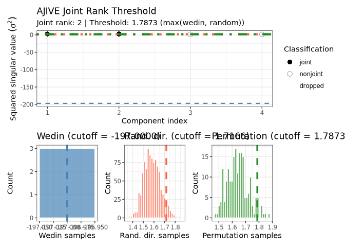

```r
# Diagnostic plot: shows obs sq-SVs against both Wedin and permutation thresholds
plot_components(fit_perm, plot_type = "ajive_diagnostic")
```

The dashed vertical line in each histogram marks the corresponding 95th-percentile threshold; the overall cut-off (dashed red line on the SV plot) is their maximum.

### Reproducibility

Permutation draws use R’s global RNG. Set `set.seed()` before calling `Rajive()` when the draws must be reproducible. The samples are also stored in `fit$joint_rank_sel$perm$perm_samples`, so the null can be inspected later without refitting.

# 3 S3 Methods — `rajive` class

## `print.rajive()`

```r
print(fit)
```

```
#> RaJIVE Decomposition
#>   Number of blocks : 3
#>   Joint rank       : 2
#>   Individual ranks : 3, 2, 2
```

**What to look for.** The print method gives the number of blocks, the estimated joint rank, and the individual rank per block. A joint rank of 0 means the fit did not detect shared signal.

## `summary.rajive()`

```r
summary(fit)
```

```
#>   block joint_rank individual_rank
#>  block1          2               3
#>  block2          2               2
#>  block3          2               2
```

**What to look for.** The summary is a tidy one-row-per-block table. It is the quick sanity check before extracting scores, loadings, or matrices.

# 4 Rank Accessors

## `get_joint_rank()`

```r
jrank <- get_joint_rank(fit)
cat("Estimated joint rank:", jrank, "\n")
```

```
#> Estimated joint rank: 2
```

## `get_individual_rank()`

```r
for (k in seq_along(blocks))
  cat(sprintf("Block %d (%s) individual rank: %d\n",
              k, names(blocks)[k], get_individual_rank(fit, k)))
```

```
#> Block 1 (mRNA) individual rank: 3
#> Block 2 (Methylation) individual rank: 2
#> Block 3 (Proteomics) individual rank: 2
```

## `get_all_ranks()`

```r
rank_tbl <- get_all_ranks(fit)
knitr::kable(rank_tbl, caption = "All block ranks")
```

All block ranks

| block | joint_rank | individual_rank |
| --- | --- | --- |
| block1 | 2 | 3 |
| block2 | 2 | 2 |
| block3 | 2 | 2 |

**What to look for.** This combines the shared rank and each block’s individual rank into one reportable table.

# 5 Component Extractors

## `get_joint_scores()`

```r
J_scores <- get_joint_scores(fit)
cat("Dimensions (samples x joint components):", dim(J_scores), "\n")
```

```
#> Dimensions (samples x joint components): 80 2
```

```r
print(round(head(J_scores, 4), 3))
```

```
#>        [,1]   [,2]
#> [1,] -0.126  0.036
#> [2,]  0.093 -0.128
#> [3,]  0.141  0.069
#> [4,]  0.028 -0.171
```

**What to look for.** Each column is one joint factor and each row is one sample. These scores are estimated, so downstream association p-values should be read as exploratory unless uncertainty is propagated.

## `get_block_scores()`

```r
bl1_joint  <- get_block_scores(fit, k = 1, type = "joint")
bl2_indiv  <- get_block_scores(fit, k = 2, type = "individual")
cat("Block 1 joint scores:", dim(bl1_joint), "\n")
```

```
#> Block 1 joint scores: 80 2
```

```r
cat("Block 2 individual scores:", dim(bl2_indiv), "\n")
```

```
#> Block 2 individual scores: 80 2
```

## `get_block_loadings()`

```r
bl1_load <- get_block_loadings(fit, k = 1, type = "joint")
cat("Block 1 joint loadings (features x components):", dim(bl1_load), "\n")
```

```
#> Block 1 joint loadings (features x components): 60 2
```

**What to look for.** Large absolute loadings mark features aligned with the component. For feature-level significance, use `jackstraw_rajive()` rather than the raw loading rank alone.

## `get_block_matrix()`

```r
J1 <- get_block_matrix(fit, k = 1, type = "joint")
I1 <- get_block_matrix(fit, k = 1, type = "individual")
E1 <- get_block_matrix(fit, k = 1, type = "noise")
cat("Reconstruction error:", round(max(abs(blocks[[1]] - J1 - I1 - E1)), 6), "\n")
```

```
#> Reconstruction error: 0
```

**What to look for.** The joint, individual, and noise matrices reconstruct the original block. The split lets you ask whether a pattern is shared across blocks or belongs mainly to one block.

# 6 Diagnostic Extraction

## `extract_components()` — `what = "rank_diagnostics"` (wide)

```r
diag_wide <- extract_components(fit, what = "rank_diagnostics", format = "wide")
cat("Cutoff rule:", diag_wide$cutoff_rule, "\n")
```

```
#> Cutoff rule: max(wedin, random)
```

```r
cat("Wedin threshold:", round(diag_wide$wedin_cutoff, 4), "\n")
```

```
#> Wedin threshold: -197
```

```r
cat("Rand-dir threshold:", round(diag_wide$rand_cutoff, 4), "\n")
```

```
#> Rand-dir threshold: 1.7173
```

```r
cat("Joint rank estimate:", diag_wide$joint_rank_estimate, "\n")
```

```
#> Joint rank estimate: 2
```

**What to look for.** The overall threshold is `max(wedin_cutoff, rand_cutoff)`. It is a useful empirical rule, not a formal FWER or FDR guarantee.

## `extract_components()` — `what = "rank_diagnostics"` (long)

```r
diag_long <- extract_components(fit, what = "rank_diagnostics", format = "long")
knitr::kable(head(diag_long, 6),
             caption = "Rank diagnostics — long format (first 6 SVs)")
```

Rank diagnostics — long format (first 6 SVs)

| component_index | obs_sval | obs_sval_sq | classification | joint_rank_estimate | overall_sv_sq_threshold | wedin_cutoff | rand_cutoff | perm_cutoff |
| --- | --- | --- | --- | --- | --- | --- | --- | --- |
| 1 | 1.653121 | 2.732808 | joint | 2 | 1.717312 | -197 | 1.717312 | NA |
| 2 | 1.606705 | 2.581503 | joint | 2 | 1.717312 | -197 | 1.717312 | NA |
| 3 | 1.171771 | 1.373047 | nonjoint | 2 | 1.717312 | -197 | 1.717312 | NA |
| 4 | 1.125616 | 1.267010 | nonjoint | 2 | 1.717312 | -197 | 1.717312 | NA |

## `extract_components()` — `what = "scores"`

```r
scores_long <- extract_components(fit, what = "scores", type = "joint",
                                  format = "long")
cat("Columns:", names(scores_long), "\n")
```

```
#> Columns: block type component sample score
```

```r
head(scores_long, 4)
```

```
#>   block  type component sample       score
#> 1     1 joint         1      1 -0.12610387
#> 2     1 joint         1      2  0.09265652
#> 3     1 joint         1      3  0.14098029
#> 4     1 joint         1      4  0.02770708
```

## `extract_components()` — `what = "loadings"`

```r
load_long <- extract_components(fit, what = "loadings", type = "joint",
                                block = 1L, format = "long")
cat("Loadings dimensions:", dim(load_long), "\n")
```

```
#> Loadings dimensions: 120 5
```

```r
head(load_long, 4)
```

```
#>   block  type component feature      loading
#> 1     1 joint         1       1 -0.096334898
#> 2     1 joint         1       2 -0.006311109
#> 3     1 joint         1       3  0.081390685
#> 4     1 joint         1       4 -0.331335060
```

## `extract_components()` — `what = "variance"`

```r
var_df <- extract_components(fit, blocks = blocks, what = "variance")
knitr::kable(round(var_df, 3), caption = "Variance explained per block (%)")
```

Variance explained per block (%)

| Joint | Indiv | Resid |
| --- | --- | --- |
| 0.321 | 0.438 | 0.241 |
| 0.334 | 0.367 | 0.299 |
| 0.271 | 0.471 | 0.258 |

# 7 Decomposition Visualization

## `data_heatmap()` — requires *reshape2*

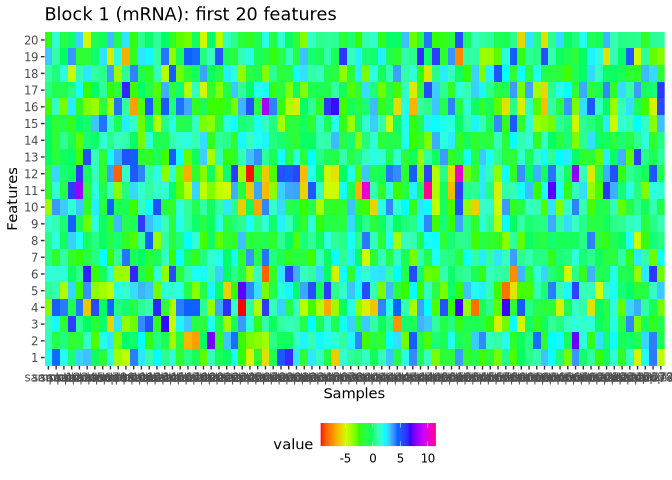

```r
if (requireNamespace("reshape2", quietly = TRUE)) {
  data_heatmap(
    data  = t(blocks[[1]][, 1:20]),
    title = "Block 1 (mRNA): first 20 features",
    xlab  = "Samples",
    ylab  = "Features"
  )
}
```

**What to look for.** Coherent color bands across samples point to latent structure before decomposition.

## `decomposition_heatmaps_robustH()` — requires *cowplot* + *reshape2*

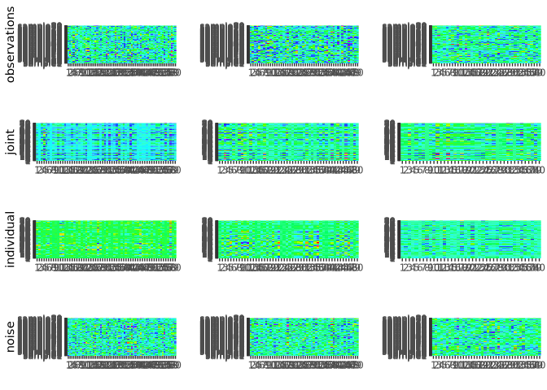

```r
if (requireNamespace("cowplot", quietly = TRUE) &&
    requireNamespace("reshape2", quietly = TRUE)) {
  decomposition_heatmaps_robustH(blocks = blocks, jive_results_robust = fit)
}
```

**What to look for.** The four panels separate original, joint, individual, and noise signal. Shared structure should appear in the joint panels across blocks; the noise panels should be comparatively featureless.

# 8 Variance Explained

## `showVarExplained_robust()`

```r
var_list <- showVarExplained_robust(fit, blocks)
cat("Joint:     ", round(unlist(var_list$Joint), 3), "\n")
```

```
#> Joint:      0.321 0.334 0.271
```

```r
cat("Individual:", round(unlist(var_list$Indiv), 3), "\n")
```

```
#> Individual: 0.438 0.367 0.471
```

```r
cat("Residual:  ", round(unlist(var_list$Resid), 3), "\n")
```

```
#> Residual:   0.241 0.299 0.258
```

## `plot_variance_explained()`

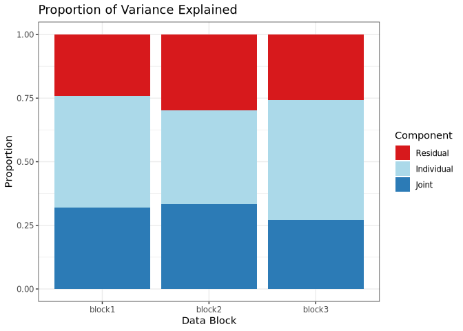

```r
plot_variance_explained(fit, blocks)
```

**What to look for.** Blocks with a large joint fraction are strongly tied to the shared signal; blocks with large individual fractions carry more view-specific biology.

# 9 Score Plots

## `plot_scores()`

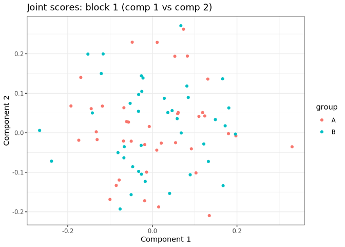

```r
jr <- get_joint_rank(fit)
if (jr >= 2) {
  plot_scores(fit, k = 1, type = "joint", comp_x = 1, comp_y = 2,
              group = meta_df$group)
} else {
  plot_scores(fit, k = 1, type = "joint", comp_x = 1,
              group = meta_df$group)
}
```

**What to look for.** Group separation along a score axis suggests the latent component tracks that metadata variable.

## `plot_components()` — `"pairs"`

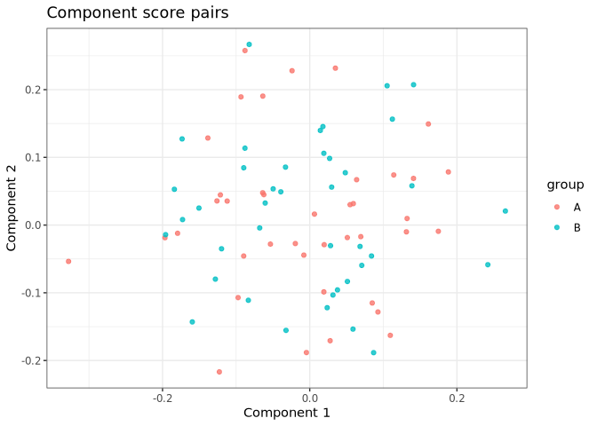

```r
plot_components(fit, plot_type = "pairs", type = "joint",
                group = meta_df$group)
```

## `plot_components()` — `"density"`

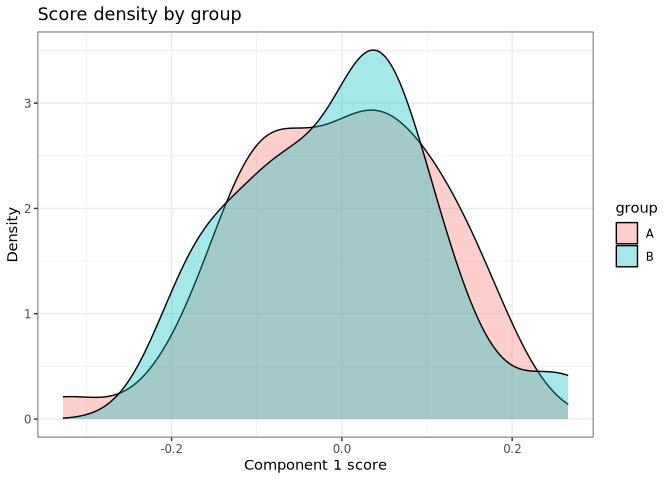

```r
plot_components(fit, plot_type = "density", type = "joint",
                group = meta_df$group)
```

**What to look for.** Bimodal densities suggest discrete sample structure. Unimodal densities point more toward a continuous gradient.

# 10 AJIVE Diagnostic Plots

## `plot_components()` — `"rank_threshold"`

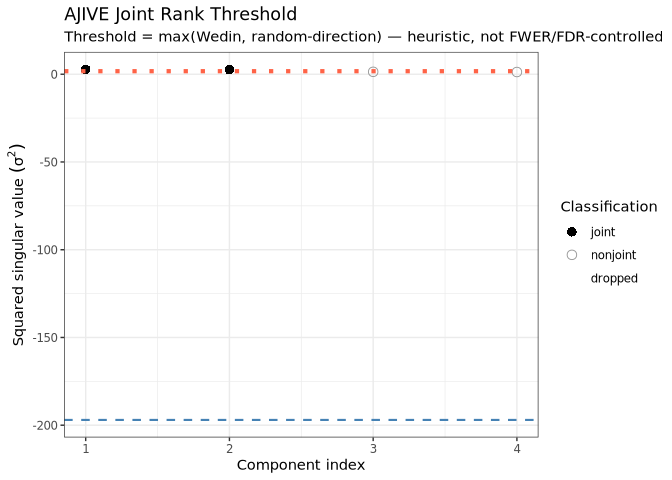

```r
plot_components(fit, plot_type = "rank_threshold") +
  labs(subtitle = "Threshold = max(Wedin, random-direction) — heuristic, not FWER/FDR-controlled")
```

**What to look for.** Squared singular values above the dashed line are called joint. A visible gap around the cutoff is more reassuring than a borderline crossing.

## `plot_components()` — `"bound_distributions"`

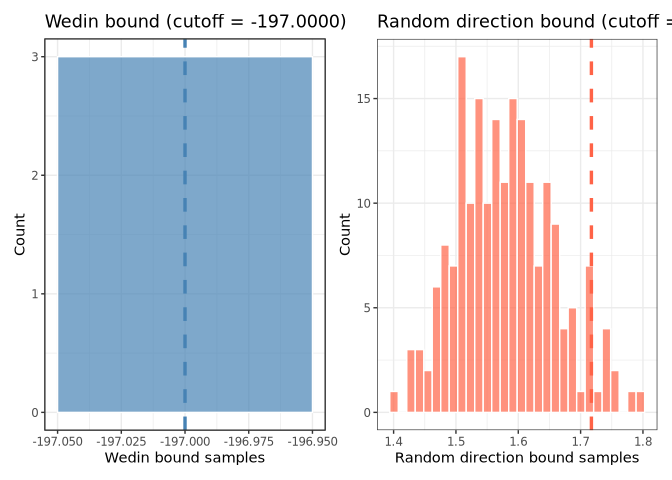

```r
plot_components(fit, plot_type = "bound_distributions")
```

**What to look for.** Narrow bound distributions give a stable threshold; wide or overlapping distributions suggest the rank decision is fragile.

## `plot_components()` — `"ajive_diagnostic"` — requires *patchwork*

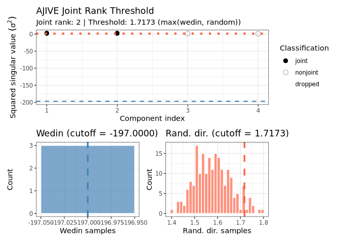

```r
if (requireNamespace("patchwork", quietly = TRUE)) {
  plot_components(fit, plot_type = "ajive_diagnostic")
}
```

**What to look for.** This is the first diagnostic to inspect. Joint components should clear both cutoffs, and the bound distributions should not make the decision look accidental.

# 11 Feature Visualization

## `plot_components()` — `"top_features"`

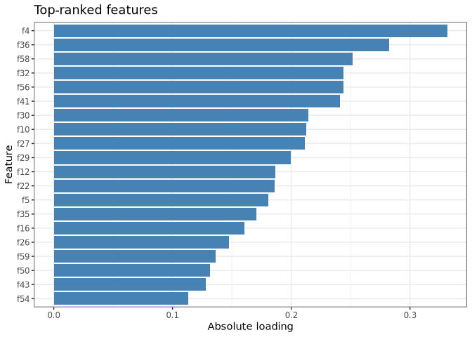

```r
plot_components(fit, plot_type = "top_features", type = "joint",
                block = 1L, component = 1L, top_n = 20L)
```

**What to look for.** The top features drive the plotted component most strongly. Treat this as ranking, not as significance.

## `plot_components()` — `"component_heatmap"`

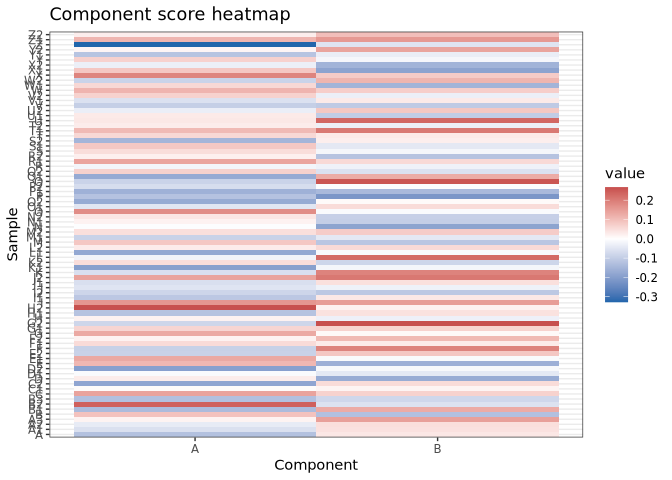

```r
plot_components(fit, plot_type = "component_heatmap", type = "joint",
                block = 1L)
```

# 12 S3 autoplot / fortify — `rajive` class

## `autoplot()`

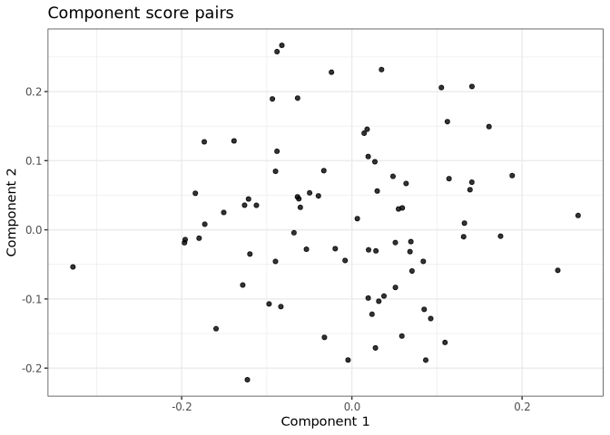

```r
autoplot(fit)
```

## `fortify()`

```r
tidy_fit <- fortify(fit)
cat("Columns:", names(tidy_fit), "\n")
```

```
#> Columns: block type component sample score
```

```r
head(tidy_fit, 3)
```

```
#>   block  type component sample       score
#> 1     1 joint         1      1 -0.12610387
#> 2     1 joint         1      2  0.09265652
#> 3     1 joint         1      3  0.14098029
```

**What to look for.** `fortify()` returns one row per sample per joint component, ready for `ggplot2` or `dplyr`.

# 13 Feature Ranking Suite

## `rank_features()` — `"top_loadings"`

```r
top20 <- rank_features(fit, mode = "top_loadings", type = "joint",
                       block = 1L, component = 1L, n = 20L, signed = TRUE)
knitr::kable(head(top20, 10), digits = 4,
             caption = "Top 10 features — Block 1, Joint Component 1")
```

Top 10 features — Block 1, Joint Component 1

| block | component | type | feature_index | feature_name | loading | abs_loading | rank |
| --- | --- | --- | --- | --- | --- | --- | --- |
| 1 | 1 | joint | 4 | NA | -0.3313 | 0.3313 | 1 |
| 1 | 1 | joint | 36 | NA | -0.2826 | 0.2826 | 2 |
| 1 | 1 | joint | 58 | NA | 0.2516 | 0.2516 | 3 |
| 1 | 1 | joint | 32 | NA | 0.2441 | 0.2441 | 4 |
| 1 | 1 | joint | 56 | NA | 0.2438 | 0.2438 | 5 |
| 1 | 1 | joint | 41 | NA | 0.2412 | 0.2412 | 6 |
| 1 | 1 | joint | 30 | NA | 0.2146 | 0.2146 | 7 |
| 1 | 1 | joint | 10 | NA | -0.2127 | 0.2127 | 8 |
| 1 | 1 | joint | 27 | NA | -0.2113 | 0.2113 | 9 |
| 1 | 1 | joint | 29 | NA | -0.1997 | 0.1997 | 10 |

**What to look for.** High absolute loadings are the strongest component drivers in this block. Use `jackstraw_rajive()` when the question is statistical significance.

## `rank_features()` — `"contribution"`

```r
contrib <- rank_features(fit, mode = "contribution", type = "joint",
                         block = 1L, component = 1L)
knitr::kable(head(contrib, 8), digits = 4,
             caption = "Feature contributions (top 8)")
```

Feature contributions (top 8)

| block | component | type | feature_index | feature_name | loading | abs_loading | contribution | rank |
| --- | --- | --- | --- | --- | --- | --- | --- | --- |
| 1 | 1 | joint | 4 | NA | -0.3313 | 0.3313 | 0.0547 | 1 |
| 1 | 1 | joint | 36 | NA | -0.2826 | 0.2826 | 0.0467 | 2 |
| 1 | 1 | joint | 58 | NA | 0.2516 | 0.2516 | 0.0415 | 3 |
| 1 | 1 | joint | 32 | NA | 0.2441 | 0.2441 | 0.0403 | 4 |
| 1 | 1 | joint | 56 | NA | 0.2438 | 0.2438 | 0.0403 | 5 |
| 1 | 1 | joint | 41 | NA | 0.2412 | 0.2412 | 0.0398 | 6 |
| 1 | 1 | joint | 30 | NA | 0.2146 | 0.2146 | 0.0354 | 7 |
| 1 | 1 | joint | 10 | NA | -0.2127 | 0.2127 | 0.0351 | 8 |

## `rank_features()` — `"overlap"`

```r
overlap <- rank_features(fit, mode = "overlap", type = "joint",
                         component = 1L, n = 50L, method = "jaccard")
knitr::kable(overlap, digits = 3,
             caption = "Jaccard overlap of top-50 joint features")
```

Jaccard overlap of top-50 joint features

| component | type | block_i | block_j | top_n | method | n_intersect | overlap_score |
| --- | --- | --- | --- | --- | --- | --- | --- |
| 1 | joint | 1 | 2 | 50 | jaccard | 40 | 0.667 |
| 1 | joint | 1 | 3 | 50 | jaccard | 32 | 0.552 |
| 1 | joint | 2 | 3 | 50 | jaccard | 40 | 0.800 |

**What to look for.** Values near 1 mean the same features dominate both blocks. Moderate overlap is common when different molecular layers share a process without sharing identical feature identities.

### Wrappers: `get_top_loadings()`, `get_feature_contributions()`, `compare_feature_sets_across_blocks()`

```r
top_w     <- get_top_loadings(fit, block = 1L, component = 1L, n = 5L)
overlap_w <- compare_feature_sets_across_blocks(fit, component = 1L,
                                                n = 50L, method = "jaccard")
cat("get_top_loadings — first row:\n"); print(top_w[1, ])
```

```
#> get_top_loadings — first row:
#>   block component  type feature_index feature_name    loading abs_loading rank
#> 1     1         1 joint             4         <NA> -0.3313351   0.3313351    1
```

```r
cat("compare_feature_sets_across_blocks:\n"); print(overlap_w)
```

```
#> compare_feature_sets_across_blocks:
#>   component  type block_i block_j top_n  method n_intersect overlap_score
#> 1         1 joint       1       2    50 jaccard          40     0.6666667
#> 2         1 joint       1       3    50 jaccard          32     0.5517241
#> 3         1 joint       2       3    50 jaccard          40     0.8000000
```

# 14 Association Testing Suite

## `associate_components()` — `"categorical"`

```r
knitr::kable(assoc_cat, digits = 4,
             caption = "Joint factor — group association (Kruskal-Wallis)")
```

Joint factor — group association (Kruskal-Wallis)

| variable | component | stat | p_value | p_adj | method |
| --- | --- | --- | --- | --- | --- |
| group | 1 | 0.0181 | 0.8928 | 0.8928 | kruskal |
| group | 2 | 0.0890 | 0.7655 | 0.8928 | kruskal |

> **Exploratory-inference caveat.** These p-values condition on estimated scores and do not propagate score uncertainty. Treat them as hypothesis-generating.

## `associate_components()` — `"continuous"`

```r
knitr::kable(assoc_cont, digits = 4,
             caption = "Joint factor — continuous association (Pearson)")
```

Joint factor — continuous association (Pearson)

| variable | component | stat | p_value | p_adj | method |
| --- | --- | --- | --- | --- | --- |
| score_cont | 1 | 0.0108 | 0.9242 | 0.9242 | pearson |
| score_cont | 2 | -0.0898 | 0.4280 | 0.8561 | pearson |

## `associate_components()` — `"survival"` (requires *survival*)

```r
assoc_surv <- associate_components(
  fit, meta_df,
  variable   = "time_event",
  mode       = "survival",
  time_col   = "time_event",
  status_col = "event_flag",
  split      = "median"
)
knitr::kable(assoc_surv, digits = 4,
             caption = "Joint factor — survival association (log-rank, median split)")
```

Joint factor — survival association (log-rank, median split)

| variable | component | stat | p_value | p_adj | method |
| --- | --- | --- | --- | --- | --- |
| time_event | 1 | 1.6707 | 0.1962 | 0.3923 | logrank_median |
| time_event | 2 | 0.0184 | 0.8920 | 0.8920 | logrank_median |

> **Survival-split note.** The median-split log-rank test is descriptive. For primary inference, prefer `split = "none"` and the continuous Cox model.

## `plot_components()` — `"association"`

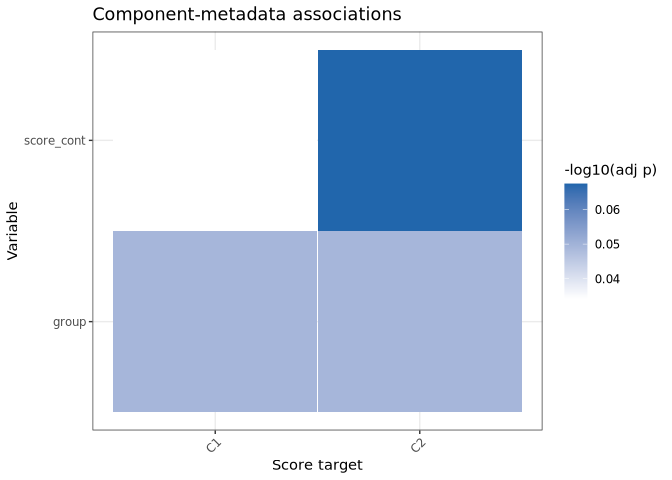

```r
assoc_all <- rbind(assoc_cat, assoc_cont)
plot_components(assoc_results = assoc_all, plot_type = "association")
```

### Wrappers: `associate_scores_continuous()`, `associate_scores_categorical()`

```r
cont_w <- associate_scores_continuous(fit, meta_df, variable = "score_cont")
cat("Same as associate_components(mode='continuous'):\n")
```

```
#> Same as associate_components(mode='continuous'):
```

```r
print(cont_w[1:2, ])
```

```
#>     variable component        stat   p_value     p_adj  method
#> 1 score_cont         1  0.01080462 0.9242185 0.9242185 pearson
#> 2 score_cont         2 -0.08984590 0.4280323 0.8560645 pearson
```

# 15 Stability Assessment Suite

## `assess_stability()` — `"joint_rank"`

```r
cat("Bootstrap joint rank distribution (B=5):\n")
```

```
#> Bootstrap joint rank distribution (B=5):
```

```r
print(stab_rank$rank_table)
```

```
#>
#> 2 3
#> 4 1
```

```r
cat("Observed rank:", stab_rank$observed_rank, "\n")
```

```
#> Observed rank: 2
```

**What to look for.** A concentrated bootstrap distribution means the selected rank is insensitive to sample resampling.

## `assess_stability()` — `"loadings"`

```r
for (k in seq_along(stab_load))
  cat(sprintf("  %s: %s\n", names(stab_load)[k],
              paste(round(stab_load[[k]]$cos_similarity, 3), collapse = ", ")))
```

```
#>   mRNA: 0.997, 0.971
#>   Methylation: 0.98, 0.978
#>   Proteomics: 0.988, 0.95
```

> **Procrustes note.** Bootstrap loadings are aligned by orthogonal Procrustes rotation before cosine similarities are computed. Cosine similarity above 0.9 is typically a stable direction.

## `assess_stability()` — `"components"`

```r
knitr::kable(stab_comp, digits = 3,
             caption = "Bootstrap stability of joint scores (B=5)")
```

Bootstrap stability of joint scores (B=5)

| component | mean_correlation | sd_correlation |
| --- | --- | --- |
| 1 | 0.974 | 0.008 |
| 2 | 0.955 | 0.033 |

## `plot_stability_heatmap()` / `plot_components(plot_type = "stability")`

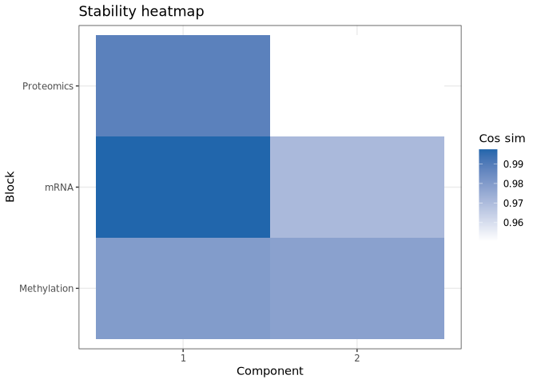

```r
plot_stability_heatmap(stab_load)
```

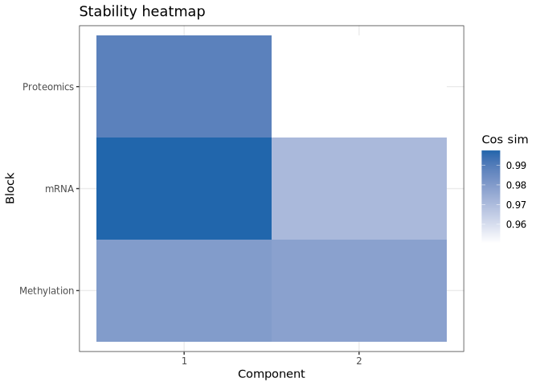

```r
plot_components(stability_result = stab_load, plot_type = "stability")
```

### Wrappers: `bootstrap_joint_rank()`, `bootstrap_loading_stability()`

```r
rank_draws <- bootstrap_joint_rank(blocks = blocks,
                                   initial_signal_ranks = c(5L, 4L, 4L),
                                   B = 5L)
load_stab  <- bootstrap_loading_stability(ajive_output = fit,
                                          blocks = blocks,
                                          initial_signal_ranks = c(5L, 4L, 4L),
                                          B = 5L)
```

# 16 Summarization Suite

## `summarize_components()` — `"components"`

```r
knitr::kable(summarize_components(fit, summary_type = "components"),
             caption = "Component catalog")
```

Component catalog

| block | type | component | block_rank | joint_rank | n_features |
| --- | --- | --- | --- | --- | --- |
| 1 | joint | 1 | 2 | 2 | 60 |
| 1 | joint | 2 | 2 | 2 | 60 |
| 1 | individual | 1 | 3 | 2 | 60 |
| 1 | individual | 2 | 3 | 2 | 60 |
| 1 | individual | 3 | 3 | 2 | 60 |
| 2 | joint | 1 | 2 | 2 | 50 |
| 2 | joint | 2 | 2 | 2 | 50 |
| 2 | individual | 1 | 2 | 2 | 50 |
| 2 | individual | 2 | 2 | 2 | 50 |
| 3 | joint | 1 | 2 | 2 | 40 |
| 3 | joint | 2 | 2 | 2 | 40 |
| 3 | individual | 1 | 2 | 2 | 40 |
| 3 | individual | 2 | 2 | 2 | 40 |

## `summarize_components()` — `"variance"`

```r
knitr::kable(
  summarize_components(fit, blocks = blocks, summary_type = "variance"),
  digits = 3,
  caption = "Variance decomposition per block"
)
```

Variance decomposition per block

| Joint | Indiv | Resid |
| --- | --- | --- |
| 0.321 | 0.438 | 0.241 |
| 0.334 | 0.367 | 0.299 |
| 0.271 | 0.471 | 0.258 |

## `summarize_components()` — `"associations"`

```r
knitr::kable(
  summarize_components(assoc_results = assoc_all, summary_type = "associations"),
  digits = 4,
  caption = "Association summary"
)
```

Association summary

|  | variable | component | n_tests | min_p_value | min_p_adj | method |
| --- | --- | --- | --- | --- | --- | --- |
| group\|\|1 | group | 1 | 1 | 0.8928 | 0.8928 | kruskal |
| group\|\|2 | group | 2 | 1 | 0.7655 | 0.8928 | kruskal |
| score_cont\|\|1 | score_cont | 1 | 1 | 0.9242 | 0.9242 | pearson |
| score_cont\|\|2 | score_cont | 2 | 1 | 0.4280 | 0.8561 | pearson |

## `summarize_components()` — `"diagnostics"`

```r
knitr::kable(head(summarize_components(fit, summary_type = "diagnostics"), 6),
             digits = 4, caption = "Rank diagnostics (first 6 rows)")
```

Rank diagnostics (first 6 rows)

| component_index | obs_sval | obs_sval_sq | classification | joint_rank_estimate | overall_sv_sq_threshold | wedin_cutoff | rand_cutoff | perm_cutoff |
| --- | --- | --- | --- | --- | --- | --- | --- | --- |
| 1 | 1.6531 | 2.7328 | joint | 2 | 1.7173 | -197 | 1.7173 | NA |
| 2 | 1.6067 | 2.5815 | joint | 2 | 1.7173 | -197 | 1.7173 | NA |
| 3 | 1.1718 | 1.3730 | nonjoint | 2 | 1.7173 | -197 | 1.7173 | NA |
| 4 | 1.1256 | 1.2670 | nonjoint | 2 | 1.7173 | -197 | 1.7173 | NA |

## `summarize_components()` — `"stability"`

```r
knitr::kable(
  summarize_components(stability_result = stab_rank, summary_type = "stability"),
  digits = 3, caption = "Bootstrap joint rank distribution"
)
```

Bootstrap joint rank distribution

| joint_rank | frequency | proportion |
| --- | --- | --- |
| 2 | 4 | 0.8 |
| 3 | 1 | 0.2 |

## `summarize_components()` — `"significance"`

```r
knitr::kable(
  summarize_components(jackstraw_result = js, summary_type = "significance"),
  digits = 4, caption = "Significant features per block x component"
)
```

Significant features per block x component

|  | block | component | n_features | n_significant | prop_significant | min_p_value | min_p_adj |
| --- | --- | --- | --- | --- | --- | --- | --- |
| 1 1 | 1 | 1 | 60 | 39 | 0.6500 | 0.0017 | 0.0055 |
| 1 2 | 1 | 2 | 60 | 35 | 0.5833 | 0.0017 | 0.0055 |
| 2 1 | 2 | 1 | 50 | 31 | 0.6200 | 0.0020 | 0.0055 |
| 2 2 | 2 | 2 | 50 | 25 | 0.5000 | 0.0020 | 0.0055 |
| 3 1 | 3 | 1 | 40 | 28 | 0.7000 | 0.0025 | 0.0055 |
| 3 2 | 3 | 2 | 40 | 23 | 0.5750 | 0.0025 | 0.0055 |

# 17 Jackstraw Significance Testing

## `jackstraw_rajive()`

```r
set.seed(42)
js <- jackstraw_rajive(
  ajive_output = fit,
  blocks       = blocks,
  alpha        = 0.05,
  n_null       = 5L,       # use >= 100 in practice
  correction   = "BH"
)
```

> **Significance note.** The jackstraw identifies features associated with the estimated joint score. It does not establish causal drivers, and the decomposition is not re-estimated after feature masking.

## `print.jackstraw_rajive()` / `summary.jackstraw_rajive()`

```r
print(js)
```

```
#> JIVE Jackstraw Significance Test
#>   Joint rank: 2   Alpha: 0.05   Correction: BH
#>
#>   Block      Component    N features     N significant
#>   ----------------------------------------------------
#>   block1     comp1        60             39
#>   block1     comp2        60             35
#>   block2     comp1        50             31
#>   block2     comp2        50             25
#>   block3     comp1        40             28
#>   block3     comp2        40             23
```

```r
summary(js)
```

```
#>   block component n_features n_significant alpha correction
#>  block1     comp1         60            39  0.05         BH
#>  block1     comp2         60            35  0.05         BH
#>  block2     comp1         50            31  0.05         BH
#>  block2     comp2         50            25  0.05         BH
#>  block3     comp1         40            28  0.05         BH
#>  block3     comp2         40            23  0.05         BH
```

## `autoplot.jackstraw_rajive()` / `fortify.jackstraw_rajive()`

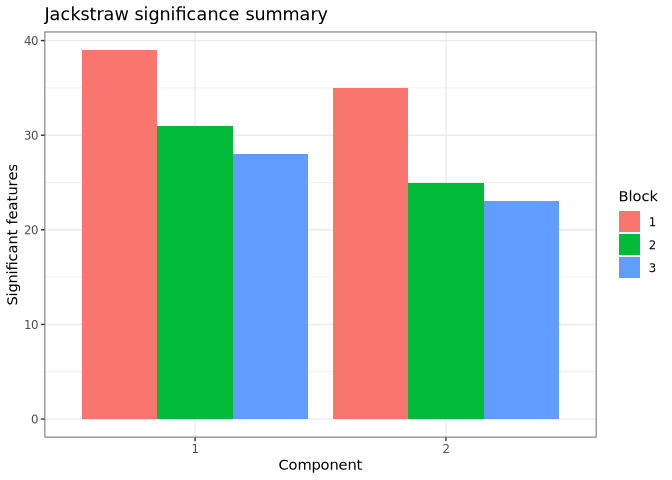

```r
autoplot(js)
```

```r
tidy_js <- fortify(js)
cat("Columns:", names(tidy_js), "\n")
```

```
#> Columns: block component feature_index p_value p_adj significant
```

```r
head(tidy_js, 4)
```

```
#>    block component feature_index     p_value       p_adj significant
#> 1      1         1             1 0.001663894 0.005500953        TRUE
#> 4      1         1             4 0.001663894 0.005500953        TRUE
#> 5      1         1             5 0.001663894 0.005500953        TRUE
#> 10     1         1            10 0.001663894 0.005500953        TRUE
```

## `plot_jackstraw()` — `"pvalue_hist"`

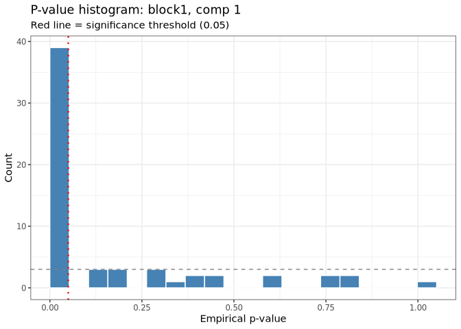

```r
plot_jackstraw(js, type = "pvalue_hist", block = 1L, component = 1L)
```

**What to look for.** A spike near zero followed by a near-uniform tail suggests real signal plus calibrated null features. A fully uniform histogram suggests little feature-level signal for that component.

## `plot_jackstraw()` — `"scatter"`

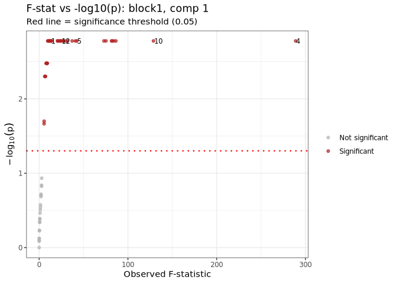

```r
plot_jackstraw(js, type = "scatter", block = 1L, component = 1L,
               label_top = 5L)
```

## `plot_jackstraw()` — `"loadings_significance"`

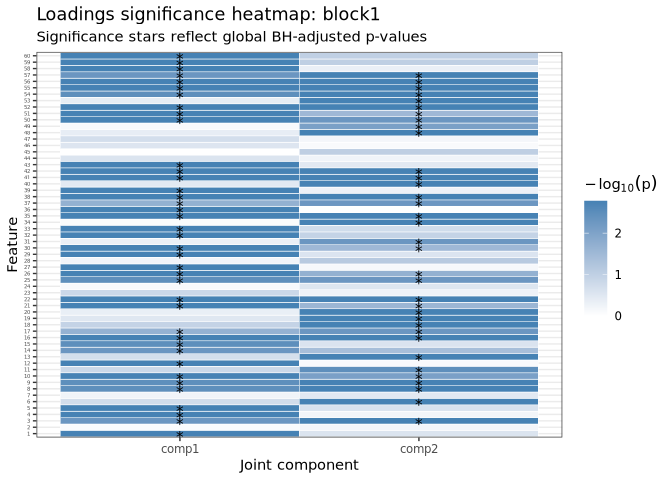

```r
plot_jackstraw(js, type = "loadings_significance", block = 1L)
```

## `plot_components()` — `"volcano"` / `"jackstraw_summary"`

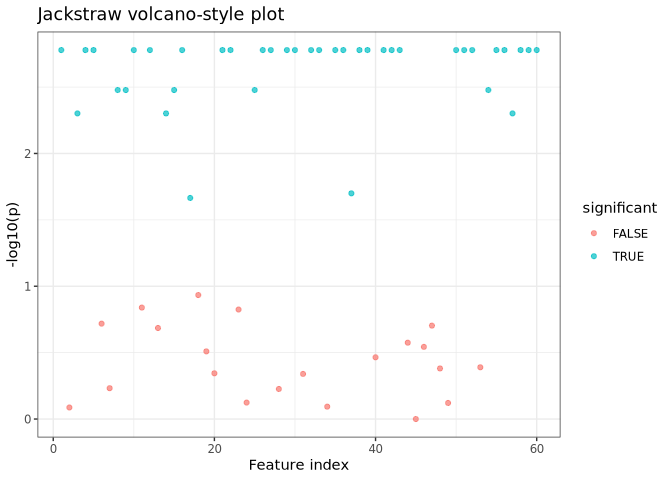

```r
plot_components(jackstraw_result = js, plot_type = "volcano",
                block = 1L, component = 1L)
```

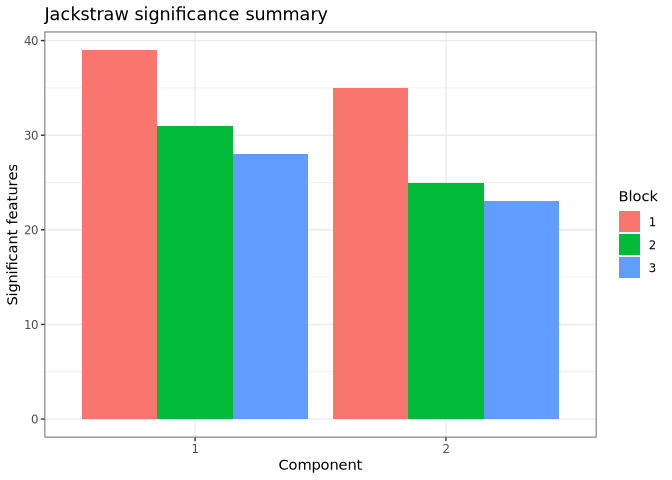

```r
plot_components(jackstraw_result = js, plot_type = "jackstraw_summary")
```

## `get_significant_vars()` / `summarize_significant_vars()`

```r
sig_b1c1 <- get_significant_vars(js, block = 1L, component = 1L)
n_sig_b1c1 <- if (is.data.frame(sig_b1c1)) nrow(sig_b1c1) else 0L
cat("Significant features (block 1, component 1):", n_sig_b1c1, "\n")
```

```
#> Significant features (block 1, component 1): 0
```

```r
if (isTRUE(n_sig_b1c1 > 0L))
  knitr::kable(head(sig_b1c1, 8), digits = 4)
```

```r
sig_all <- summarize_significant_vars(js)
if (is.data.frame(sig_all) && nrow(sig_all) > 0L) {
  knitr::kable(head(sig_all, 8), digits = 4,
               caption = "All significant features (all blocks x components)")
} else {
  knitr::kable(tibble::tibble(message = "No significant features at the current threshold."))
}
```

All significant features (all blocks x components)

|  | block | component | feature_index | p_value | p_adj | significant |
| --- | --- | --- | --- | --- | --- | --- |
| 1 | 1 | 1 | 1 | 0.0017 | 0.0055 | TRUE |
| 4 | 1 | 1 | 4 | 0.0017 | 0.0055 | TRUE |
| 5 | 1 | 1 | 5 | 0.0017 | 0.0055 | TRUE |
| 10 | 1 | 1 | 10 | 0.0017 | 0.0055 | TRUE |
| 12 | 1 | 1 | 12 | 0.0017 | 0.0055 | TRUE |
| 16 | 1 | 1 | 16 | 0.0017 | 0.0055 | TRUE |
| 21 | 1 | 1 | 21 | 0.0017 | 0.0055 | TRUE |
| 22 | 1 | 1 | 22 | 0.0017 | 0.0055 | TRUE |

# 18 Reporting and Export

## `export_results()` — `"csv"` / `"rds"`

```r
top_feats <- rank_features(fit, mode = "top_loadings", type = "joint",
                           block = 1L, component = 1L, n = 20L)
tmp_csv <- tempfile(fileext = ".csv")
export_results(top_feats, path = tmp_csv, format = "csv")
rt <- read.csv(tmp_csv)
cat("Round-trip rows/cols:", nrow(rt), "/", ncol(rt), "\n")
```

```
#> Round-trip rows/cols: 20 / 8
```

```r
tmp_rds <- tempfile(fileext = ".rds")
export_results(fit, path = tmp_rds, format = "rds")
fit2 <- readRDS(tmp_rds)
cat("Reloaded joint rank:", get_joint_rank(fit2), "\n")
```

```
#> Reloaded joint rank: 2
```

## `rajive_report()`

```r
tmp_html <- tempfile(fileext = ".html")
rajive_report(
  ajive_output     = fit,
  blocks           = blocks,
  metadata         = meta_df,
  jackstraw_result = js,
  output_file      = tmp_html,
  sections         = c("overview", "variance", "features",
                       "associations", "stability")
)
cat("Report written to:", tmp_html, "\n")
```

```
#> Report written to: /tmp/RtmpRAlbVA/file26fe2d71613dae.html
```

```r
cat("File size (bytes):", file.info(tmp_html)$size, "\n")
```

```
#> File size (bytes): 6346
```

**What to look for.** The report is a portable review artifact. For final analysis decisions, use the specialized tables and plots shown above.

# 19 Appendix — Wrapper Quick Reference

| Wrapper | Equivalent underlying call |
| --- | --- |
| `get_top_loadings(fit, block=1, component=1)` | `rank_features(fit, mode="top_loadings", block=1, component=1)` |
| `get_feature_contributions(fit, block=1)` | `rank_features(fit, mode="contribution", block=1)` |
| `compare_feature_sets_across_blocks(fit, n=50)` | `rank_features(fit, mode="overlap", n=50)` |
| `summarize_significant_vars(js)` | `rank_features(jackstraw_result=js, mode="significant")` |
| `associate_scores_continuous(fit, meta, variable="x")` | `associate_components(fit, meta, variable="x", mode="continuous")` |
| `associate_scores_categorical(fit, meta, variable="g")` | `associate_components(fit, meta, variable="g", mode="categorical")` |
| `associate_scores_survival(fit, meta, time_col="t", status_col="e")` | `associate_components(fit, meta, mode="survival", time_col="t", status_col="e")` |
| `bootstrap_joint_rank(blocks=blocks, initial_signal_ranks=ranks, B=5)` | `assess_stability(blocks=blocks, initial_signal_ranks=ranks, target="joint_rank", B=5)` |
| `bootstrap_loading_stability(fit, blocks, ranks, B=5)` | `assess_stability(fit, blocks, ranks, target="loadings", B=5)` |
| `plot_stability_heatmap(stab_load)` | `plot_components(stability_result=stab_load, plot_type="stability")` |